# Lab_03

## 3η Εργαστηριακή Άσκηση

### Όνομα : Αλεξανδρόπουλος Σταμάτης

### Αριθμός Μητρώου : 03117060

### Ερωτήσεις κατανόησης

##### 1. Γιατί σε λογαριθμική κλίμακα βλέπουμε μια ευθεία;

*Απάντηση*

Ισχύει ότι $log_2( 32x^3 ) = 3log_2(x) + log_2(32)= 3log_2(x) + log_2(2^5) = 3log_2(x) + 5 $ . Θέτω $ X = log_2x $. Οπότε η προηγούμενη σχέση γράφεται $ 3X + 5 $ που είναι της μορφής y=a*x + b που είναι γραμμική σχέση. Γιαυτό το λόγο βλέπουμε μια ευθεία.

##### 2. Εκτιμήστε γραφικά την κλίση της ευθείας και το σημείο που τέμνει τον άξονα $logx=0$.

*Απάντηση*

Από το πρώτο ερώτημα έχουμε ότι η ευθεία είναι της μορφής y=a*x + b με κλίση α=3 και b=5. Όσον αφορά το σημείο τομής, θέτουμε $X = logx = 0$ και άρα το σημείο τομής με τον κατακόρυφο άξονα είναι το (0,$log(32)) =(0,5) $.

##### 3. Δοκιμάστε να κατασκευάσετε ίδιο γράφημα τις γραφικές παρατάσεις των συναρτήσεων $y = 8x^3$ και $y = 8x^2$. Πως αλλάζει η κλίση για τις 2 αυτές συναρτήσεις;

*Απάντηση*

Τροποποιώντας τον κώδικα κάνουμε τις ζητούμενες γραφικές παραστάσεις. Παρατηρούμε ότι όταν $y = 8x^3$ η κλίση παραμένει ίση με 3, ενώ αλλάζει η κατακόρυφη μετατόπιση αφού με την ίδια λογική με προηγουμένως ισχύει $log_2( 8x^3 ) = 3log_2(x) + log_2(8)= 3log_2(x) + log_2(2^3) = 3log_2(x) + 3 =3X +3$ , ενώ για $y = 8x^2$ η κλίση είναι 2, με την ίδια λογική. Οι γραφικές τους παραστάσεις φαίνονται παρακάτω

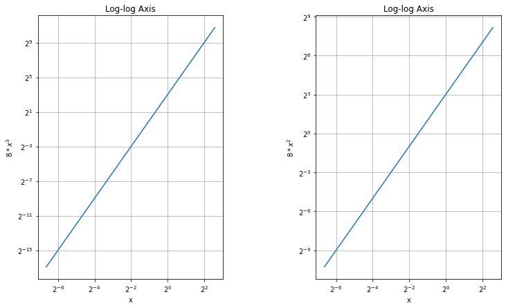

```python
import numpy as np  # numerical computations library. We will call it np in our code
import matplotlib.pyplot as plt  # library for plotting. We will call it plt in our code
# to plot the results in the notebook:
%matplotlib inline


# Create a list of real numbers from start to end by step
start, end, step = 0.01, 6.0, 0.01
x = np.arange(start, end, step)  # x = [0.01, 0.02, ..., 5.99, 6.00]
#New functions
y_1 = 8 * x**3
y_2 = 8 * x**2

plt.figure(figsize=(12, 7))  # define figure size

# Right Axes
plt.subplot(1, 2, 1)  # setup subplots 1-row, 2-cols, select the 1st
plt.loglog(x, y_1, base=2)
plt.xlabel('x')
plt.ylabel('$8*x^3$')
plt.title('Log-log Axis')
plt.grid()  # add grid-lines

# Left Axes
plt.subplot(1, 2, 2) # select the 2nd subplot
plt.loglog(x, y_2, base=2)
plt.xlabel('x')
plt.ylabel('$8*x^2$')
plt.title('Log-log Axis')
plt.grid()

plt.subplots_adjust(wspace = 0.5)
plt.show() # FIXME Enabled!
```

## Παραδοτέο 1

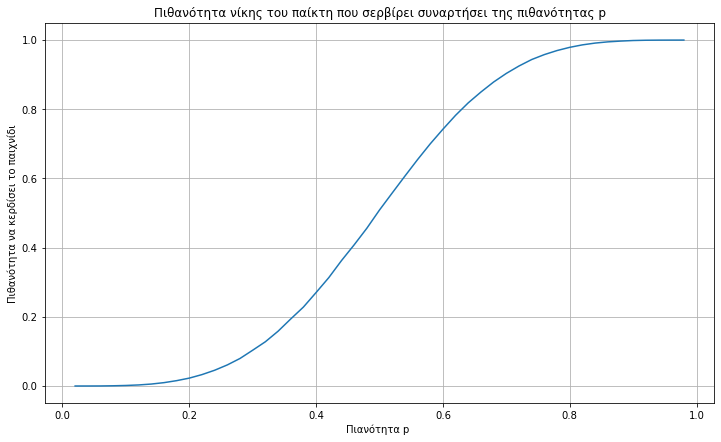

```python
import random
import numpy as np
import statistics as stat
from simple_markov_chain_lib import markov_chain
random.seed(2021)  # for reproducibility


p_list=np.arange( 0.02,1.0, 0.02 ) #list of all probabilities
total_list=[]
for p in p_list:
    initial_probs = {"0-0": 1.0}
    q=1-p
    markov_table = {
        "0-0": { "15-0": p,"0-15": q},
        "15-0": { "30-0": p,"15-15":q},
        "0-15": {"15-15": p,"0-30": q },
        "30-0": { "40-0": p,"30-15": q },
        "15-15": { "30-15": p,"15-30": q },
        "0-30": { "15-30": p,"15-40": q },
        "40-0": { "GameA": p,"40-15": q },
        "30-15": { "40-15": p,"Deuce": q },
        "15-30": { "Deuce": p,"15-40": q },
        "0-40": { "15-40": p,"GameB": q },
        "40-15": { "GameA": p,"AdvA": q },
        "Deuce": { "AdvA": p,"AdvB": q },
        "15-40": { "AdvB": p,"GameB": q},
        "GameA": { "GameA": 1.0 },
        "AdvA": { "GameA": p,"Deuce": q },
        "AdvB": { "Deuce": p,"GameB": q},
        "GameB": { "GameB": 1.0 },
    }

    mc = markov_chain( markov_table, initial_probs)

    #Experiment
    N=20000
    list_track=[]
    count=0
    for i in range(10):
        for i in range(N):
            mc.start()
            while mc.running_state not in ["GameA","GameB"]:
                mc.move()
            if mc.running_state=="GameA":
                count += 1
        mean=count/N
        list_track.append(mean)
        count=0
    result= np.mean(list_track)
    total_list.append(result)
    list_track.clear()
plt.figure(figsize=(12, 7))
plt.subplot()
plt.plot(p_list,total_list)
plt.xlabel("Πιανότητα p ")
plt.ylabel("Πιθανότητα να κερδίσει το παιχνίδι")
plt.title("Πιθανότητα νίκης του παίκτη που σερβίρει συναρτήσει της πιθανότητας p")
plt.grid(True)
plt.show()
```

#### Σχολιασμός της μορφής της γραφικής παράστασης

Η παραπάνω γραφική παράσταση της πιθανότητας νίκης $F(p)$ συναρτήση της πιθανότητας p, δηλαδή της πιθανότητας ο παίκτης που σερβίρει να κερδίσει τον κάθε πόντο είναι γνησίως αύξουσα συνάρτηση. Αυτό είναι λογικό αφού όσο αυξάνεται η πιθανότητα να κερδίσει ο παίκτης ένα πόντο τόσο και πιο μεγάλη είναι η πιθανότητα να κερδίσει το παιχνίδι. Παρατηρούμε ότι, για $p=0.6$ η τιμή της πιθανότητας νίκης είναι κοντά στο $F(p) = 0.7$ όπως είχαμε υπολογίσει και στην 2η σειρά εργαστηριακών άσκήσεων (συγκεκριμένα 0.74146).

###### Ακρότατα

Η γραφική παράσταση παρουσιάζει ολικό ελάχιστο το $F(p)=0$ όταν $p = 0$ και ολικό μέγιστο το $F(p) = 1$ όταν $p = 1$. Αυτές είναι και οι αναμενόμενες τιμές.

### Άσκηση

και αρχική κατανομή:

$$ \pi_0 = (1, 0, 0, 0, 0 ) $$

Ο κώδικας της άσκησης είναι ο εξής:

```python
import random
import statistics as stat
import matplotlib.pyplot as plt
import numpy as np

from simple_markov_chain_lib import markov_chain  # import markov chain simulator

%matplotlib inline

# Transition Table
markov_table = {
    0: {1: .5, 2: .5},  # from state 0 we move to state 1 with prob 0.5 and to state 2 with 0.5
    1: {0: 1/3, 3: 2/3},
    2: {2: 1.},
    3: {0: .5, 3: .25, 4: .25},
    4: {4: 1.}
}

# Initial Distribution
init_dist = {0: 1.}  # we start from state 0 with probability 1

M = 30 #we run the experiment 30 times for every sample_size

mc = markov_chain(markov_table, init_dist)


list_sam = []
list_var = []
N = np.arange(2**5,2**12,4)
for sample_size in N:
    total_list = []
    for runs in range( M ):
        running_total = 0
        for i in range(sample_size):
            mc.start()
            while mc.running_state != 2 and mc.running_state != 4:
                mc.move()
            running_total += mc.steps  # steps it took to be absorbed

        mc_estimate = running_total / sample_size
        total_list.append( mc_estimate )

    list_var.append(stat.variance( total_list ))
    list_sam.append(sample_size)

plt.figure(figsize=(12, 7))  # define figure size
```

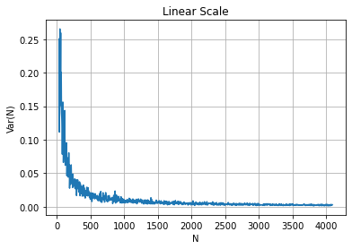

```python
# Right Axes
plt.plot(N, list_var)
plt.xlabel('N')
plt.ylabel('Var(N)')
plt.title('Linear Scale')
plt.grid(True)  # add grid-lines
plt.show()
```

```
Η ζητούμενη κλήση της ευθείας είναι: -0.996636710163044
```

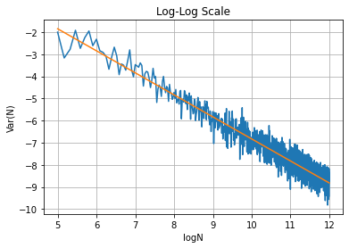

```python
(a,b) = np.polyfit(np.log2(N),np.log2(list_var),1)

Y = a * np.log2(N) + b

print('Η ζητούμενη κλήση της ευθείας είναι: {0}'.format(a))
plt.plot(np.log2(N), np.log2(list_var))
plt.plot(np.log2(N),Y)
plt.xlabel('logN')
plt.ylabel('Var(N)')
plt.title('Log-Log Scale')
plt.grid(True)
plt.show()
```

Παρατηρούμε ότι η γραφική παράσταση συμφωνεί με την θεωρία καθώς η διασπορά των εκτημίσεων μειώνεται με την αύξηση των δειγμάτων. Συγκεκριμένα έστω $Y_i = ( X_i - μ ) ^ 2$ ανεξάρτητες, ισόνομες τυχαίες μεταβλητές με μέση τιμή $\mathbb{E} [ Y_i ] = \mathbb{E} [ ( X_i - μ ) ^2 ] = \sigma _X ^2$.

Αν $Var(x) = \frac{1}{N}\sum_{i=1}^{N} (X_i - μ)^2$, τότε $Var(x) =\frac{1}{N} \sum_{i=1}^{N} Y_i = \frac{\sqrt{N}}{\sqrt{N}} ( \frac{1}{N} \sum_{i=1}^{N} Y_i - μ_Υ ) + μ_Υ $.

Από Κ.Ο.Θ έχουμε